# SUMÁRIO

- 1. INTRODUÇÃO
- 2. PREPARAÇÕES INICIAIS E CONFIGURAÇÕES
  - 2.1. IMPORTAÇÃO DE BIBLIOTECAS
  - 2.2. CONFIGURAÇÕES DE PLOTAGEM
  - 2.3. DATASET
    - 2.3.1. CARREGANDO DATASET
    - 2.3.2. CABEÇALHO
    - 2.3.3. INFORMAÇÕES
  - 2.4. COMPREENSÃO DOS DADOS
    - 2.4.1. COLUNAS
  - 2.5. PREPARANDO DADOS
    - 2.5.1. VALORES NULOS
      - 2.5.1.1. IDENTIFICANDO COLUNAS
      - 2.5.1.2. MANIPULAÇÃO DOS NOMES DAS COLUNAS
      - 2.5.1.3. IDENTIFICANDO LINHAS
      - 2.5.1.4. LIDANDO COM OS VALORES NULOS
    - 2.5.2. FORMATAÇÃO DE DADOS
      - 2.5.2.1. DADOS NUMÉRICOS
  - 2.6. DEFININDO FUNÇÕES AUXILIARES
    - 2.6.1. FUNÇÃO DESCRIBETTER
    - 2.6.2. FUNÇÃO UNIVARIATE_MULTI_PLOT
    - 2.6.3. FUNÇÃO UNIVARIATE_SINGLE_PLOT
    - 2.6.4. FUNÇÃO UNIVARIATE_NUMERICAL_PLOT
    - 2.6.5. FUNÇÃO MULTIVARIATE_PLOT
    - 2.6.6. FUNÇÃO MULTIVARIATE_COUNT_PLOT
- 3. ANÁLISE EXPLORATÓRIA
  - 3.1. ANÁLISE UNIVARIADA
    - 3.1.1. PAÍSES
    - 3.1.2. RECEITA DE DEFESA (2020)
    - 3.1.3. RECEITA DE DEFESA (2019)
    - 3.1.4. VARIAÇÃO NA RECEITA DE DEFESA (2019 PARA 2020)
    - 3.1.5. RECEITA TOTAL (2020)
    - 3.1.6. PROPORÇÃO - RECEITA DE DEFESA X RECEITA TOTAL (2020)

# 1. INTRODUÇÃO

Olá. Meu nome é Caio e esta é a minha primeira análise de dados documentada. Escolhi para análise uma base de dados sobre fabricantes de defesa militar. Ao longo deste documento irá conter toda uma preparação de dados, a análise exploratória dos mesmos e suas considerações finais. Sou uma pessoa de mente aberta e aceito críticas construtivas. Boa leitura!

[figure not shown]

# 2. PREPARAÇÕES INICIAIS E CONFIGURAÇÕES

## 2.1. IMPORTAÇÃO DE BIBLIOTECAS

```python
import country_converter as coco
import numpy as np
import pandas as pd
import matplotlib.pyplot as plt
import seaborn as sns
import country_converter as coco
import warnings
import re

warnings.filterwarnings("ignore")
np.set_printoptions(precision=5)
```

## 2.2. CONFIGURAÇÕES DE PLOTAGEM

```python
plt.rcParams['figure.dpi'] = 300
plt.rcParams['savefig.dpi'] = 300

font = {'family':'Helvetica, Ariel',
        'weight':'normal',
        'size':12}

plt.rc('font', **font)

sns.set(rc={"figure.dpi": 300, 'savefig.dpi': 300})
sns.set_context('notebook')
sns.set_style("ticks")
sns.set_palette("Accent")

FIG_FONT = dict(family="Helvetica, Ariel", weight="bold", color="#7f7f7f")
```

## 2.3. DATASET

### 2.3.1. CARREGANDO DATASET

```python
df = pd.read_csv('top_defense_manufacturers.csv')
```

### 2.3.2. CABEÇALHO

```python
df.head(3)
```

|  | this_year_rank | last_year_rank | company | leadership | country | 2020_defense_revenue | 2019_defense_revenue | %_defense_revenue_change | 2020_total_revenue | revenue_fom_defense |
| --- | --- | --- | --- | --- | --- | --- | --- | --- | --- | --- |
| 0 | 1 | 1 | Lockheed Martin 1 2 | James D. Taiclet, Chairman, President and CEO | U.S. | $62,562.00 | $56,606.00 | 11% | $65,398.00 | 96% |
| 1 | 2 | NEW | Raytheon Technologies 3 | Greg Hayes, CEO and Executive Chairman | U.S. | $42,000.00 | NaN | NaN | $65,000.00 | 65% |
| 2 | 3 | 2 | Boeing 4 | David Calhoun, President and CEO | U.S. | $32,400.00 | $34,300.00 | -6% | $58,158.00 | 56% |

### 2.3.3. INFORMAÇÕES

```python
df.info()
```

```
<class 'pandas.core.frame.DataFrame'>
RangeIndex: 100 entries, 0 to 99
Data columns (total 10 columns):
 #   Column                     Non-Null Count  Dtype
---  ------                     --------------  -----
 0   this_year_rank             100 non-null    int64
 1   last_year_rank             100 non-null    object
 2   company                    100 non-null    object
 3   leadership                 100 non-null    object
 4   country                    100 non-null    object
 5   2020_defense_revenue       100 non-null    object
 6   2019_defense_revenue       89 non-null     object
 7   %_defense_revenue_change   89 non-null     object
 8   2020_total_revenue         100 non-null    object
 9   revenue_fom_defense        100 non-null    object
dtypes: int64(1), object(9)
memory usage: 7.9+ KB
```

## 2.4. COMPREENSÃO DE DADOS

Para uma progressão linear da análise é necessário compreender os dados da base.

- **this_year_rank**: Classificação da fabricante entre as listadas no dataset (2020). Valores compreendidos entre 1 e 100. Os dados estão ordenados de forma ascendente através desta coluna;
- **last_year_rank**: Classificação da fabricante entre as listadas no dataset (2019). Valores compreendidos entre 1 e 100;
- **company**: Nome da fabricante;
- **leadership**: Nome seguido do cargo dos representantes da empresa. Sintaxe: "Nome, Cargo, Nome, Cargo...";
- **country**: País de origem da fabricante;
- **2020_defense_revenue**: Receita originada dos sistemas de defesa da fabricante no ano de 2020 em milhões de dólares. Unidade: $US Million;
- **%_defense_revenue_change**: Proporção de ganho/perda da empresa em relação ao ano anterior com origem nos sistemas de defesa fabricados.  
  Fórmula: %_defense_revenue_change = ((2020_defense_revenue / 2019_defense_revenue) * 100) - 100
- **2020_total_revenue**: Receita total da empresa, incluindo a receita originada dos sistemas de defesa fabricados, ativos e passivos.  
  Fórmula: 2020_total_revenue = 2020_defense_revenue + 2020_other_revenues. A coluna "2020_other_revenues" não existe no dataset.
- **revenue_from_defense**: Proporção de receita originada dos sistemas de defesa pela receita total da empresa.  
  Fórmula: revenue_from_defense = (2020_defense_revenue / 2020_total_revenue) * 100

## 2.5. PREPARANDO DADOS

### 2.5.1. VALORES NULOS

#### 2.5.1.1. IDENTIFICANDO COLUNAS

Através das informações do DataFrame, foi possível identificar que o arquivo possui 100 linhas, sendo que duas colunas apresentam 11 valores nulos. Estas colunas são:

- "2019_defense_revenue"
- "%_defense_revenue_change"

#### 2.5.1.2. MANIPULAÇÃO DOS NOMES DAS COLUNAS

As colunas foram renomeadas de modo que tornasse a análise mais eficiente.

- Os nomes começando com caracteres numéricos tiveram os mesmos deslocados para o final do nome;
- Os caracteres especiais foram substituídos pelo seu nome literal.

```python
df.columns = ['this_year_rank', 'last_year_rank', 'company', 'leadership', 'country', 'defense_revenue_2020', 'defense_revenue_2019', 'percent_defense_revenue_change', 'total_revenue_2020', 'revenue_from_defense']
```

#### 2.5.1.3. IDENTIFICANDO LINHAS

Linhas contendo valores nulos armazenados na variável "df_nan"

```python
df_nan = df[df.isna().any(axis=1)]
display(df_nan)
```

[output not shown]

#### 2.5.1.4. LIDANDO COM OS VALORES NULOS

Através da visualização das linhas é possível realizar as seguintes considerações:

- Os valores nulos se encontram em um grupo de linhas onde a coluna "last_year_rank" possui o dado "NEW".
- O dado "NEW" representa empresas novas, levando a deixar as colunas de dados anteriores em branco.

Através destas considerações é possível afirmar que não houve erro e os dados não devem ser removidos por completo, apenas de análises de correlações entre dados atuais e anteriores.

### 2.5.2. FORMATAÇÃO DE DADOS

#### 2.5.2.1. DADOS NUMÉRICOS

Formatando valores string para melhor conversão em valores numéricos

```python
df['defense_revenue_2020'] = df['defense_revenue_2020'].replace(to_replace=r'[\,, \$]', value="", regex=True)
df['defense_revenue_2020'] = df['defense_revenue_2020'].astype(float)

df['defense_revenue_2019'] = df['defense_revenue_2019'].replace(to_replace=r'[\,, \$]', value="", regex=True)
df['defense_revenue_2019'] = df['defense_revenue_2019'].astype(float)

df['percent_defense_revenue_change'] = df['percent_defense_revenue_change'].replace(to_replace=r'\%', value="", regex=True)
df['percent_defense_revenue_change'] = df['percent_defense_revenue_change'].astype(float)

df['total_revenue_2020'] = df['total_revenue_2020'].replace(to_replace=r'[\,, \$]', value="", regex=True)
df['total_revenue_2020'] = df['total_revenue_2020'].astype(float)

df['revenue_fom_defense'] = df['revenue_from_defense'].replace(to_replace=r'\%', value="", regex=True)
df['revenue_fom_defense'] = df['revenue_from_defense'].astype(float)
```

```python
df.head(3)
```

[output not shown]

## 2.6. DEFININDO FUNÇÕES AUXILIARES

### 2.6.1. FUNÇÃO DESCRIBETTER

Função auxiliar para acrescentar os valores mínimos e máximos do boxplot desconsiderando os outliers à função describe da biblioteca pandas.

```python
def describetter(df, column):

    # Cálculo dos Quartis
    q1 = df.quantile(0.25)
    q3 = df.quantile(0.75)

    # Cálculo do Intervalo Quartílico
    iqr = q3 - q1

    # Cáculo dos Limites (Desconsiderando Valores Mínimos e Máximos)
    lower_fence = q1 - (1.5 * iqr)
    upper_fence = q3 + (1.5 * iqr)

    # Definição do Limite Mínimo e Máximo Baseado nos Valores
    upper_result = max(df[df<upper_fence])
    lower_result = min(df[df>lower_fence])

    # Concatenação dos Resultados num Dict
    min_max_dict = {
        'min_no': lower_result,
        'max_no': upper_result
    }

    #Criação do DataFrame min_max_no
    min_max_no = pd.DataFrame.from_dict([min_max_dict]).transpose()

    #Renomeando Coluna
    min_max_no.columns = [column]

    # Concatenação de DataFrames (pd.DataFrame.describe() + min_max_no)
    result = pd.concat([pd.DataFrame(df.describe()), min_max_no])

    # Retorno do Resultado
    return result
```

### 2.6.2. FUNÇÃO UNIVARIATE_MULTI_PLOT

Função para exibir o gráfico de pizza e o gráfico de barras de um dataframe numa análise univariada

```python
# df = data frame
# x = valores do eixo x
# xlabel = texto do eixo x
# explode = expressão bool para separação da maior fatia do gráfico de pizza

def univariate_multi_plot(df=df, x=None, xlabel=None, explode=None):
    fig, ax = plt.subplots(1, 2, figsize=(20, 7))
    sns.countplot(data=df, x=x, ax=ax[0], order=df[x].value_counts(ascending=True).index)
    df[x].value_counts(ascending=True).plot(kind="pie", autopct="%1.1f%%", ax=ax[1], explode=explode)
    sns.despine(bottom=True, left=True)
    ax[0].set_xlabel(xlabel=xlabel, size=12, fontdict=FIG_FONT)
    ax[0].set_ylabel(ylabel="")
    ax[1].set_ylabel(ylabel="")
    ax[0].bar_label(ax[0].containers[0], label_type='edge', size=12, padding=1, fontname="DejaVu Sans",
                    color="#7f7f7f")
    fig.text(0.5, 1, f'{xlabel}', size=16, fontdict=FIG_FONT, ha="center", va="center")
    plt.show()
```

### 2.6.3. FUNÇÃO UNIVARIATE_SINGLE_PLOT

Função para exibir o gráfico de barras de um dataframe numa análise univariada

```python
# df = data frame
# x = valores do eixo x
# xlabel = texto do eixo x
# rotation = grau de rotação em graus do texto do eixo x
# bar_label = expressão bool para exibição do texto da barra

def univariate_single_plot(df=df, x=None, xlabel=None, rotation=None, bar_label=False):
    fig, ax = plt.subplots(1, 1, figsize=(20, 7))
    sns.countplot(data=df, x=x, order=df[x].value_counts(ascending=True).index)
    sns.despine(bottom=True, left=True)
    plt.xlabel(xlabel=xlabel, size=14, fontdict=FIG_FONT)
    plt.xticks(rotation=rotation)
    plt.ylabel(ylabel="")
    if bar_label:
        ax.bar_label(ax.containers[0], label_type='edge', size=10, padding=1, fontname="DejaVu Sans",
                        color="#7f7f7f")
    plt.title(label=f'{xlabel}', size=18, fontdict=FIG_FONT)
    plt.show()
```

### 2.6.4. FUNÇÃO UNIVARIATE_NUMERICAL_PLOT

Função para exibir o gráfico de barras numérico e boxplot de um dataframe numa análise univariada

```python
# df = data frame
# x = valores do eixo x
# xlabel = texto do eixo x
# bar_label = expressão bool para exibição do texto da barra

def univariate_numerical_plot(df=df, x=None, xlabel=None, bar_label=True):
    fig, ax = plt.subplots(1, 2, figsize=(20, 7))
    sns.histplot(data=df, x=x, kde=True, ax=ax[0])
    sns.boxplot(data=df, x=x, ax=ax[1])
    sns.despine(bottom=True, left=True)
    ax[0].set_xlabel(xlabel=xlabel, size=12, fontdict=FIG_FONT)
    ax[1].set_xlabel(xlabel=xlabel, size=12, fontdict=FIG_FONT)
    ax[0].set_ylabel(ylabel="")
    ax[1].set_ylabel(ylabel="")
    fig.text(0.5, 1, f'{xlabel}', size=16, fontdict=FIG_FONT, ha="center", va="center")
    plt.show()
```

### 2.6.5. FUNÇÃO MULTIVARIATE_PLOT

Função para exibir o gráfico de barras de um dataframe numa análise multivariada

```python
# df = data frame
# x = valores do eixo x
# y = valores no eixo y
# hue = título da legenda do gráfico
# xlabel = texto do eixo x
# ylabel = texto do eixo y
# rotation = grau de rotação em graus do texto do eixo x
# bar_label = expressão bool para exibição do texto da barra
# legend = expressão bool para exibição da legenda do gráfico
# rotate_label = expressão bool para definir se o texto do eixo x deve girar

def multivariate_plot(df=df, title=None, x=None, y=None, hue=None, xlabel=None, ylabel=None, rotation=None, bar_label=True,
                      legend=False, rotate_label=False):
    fig, ax = plt.subplots(1, 1, figsize=(20, 7))
    df = df.groupby(x).mean()[y].sort_values().reset_index().copy()
    sns.barplot(data=df, x=x, y=y, hue=hue, ci=None)
    plt.ylabel(ylabel=ylabel, size=12, fontdict=FIG_FONT)
    plt.xlabel(xlabel=xlabel, size=12, fontdict=FIG_FONT)
    plt.title(label=title, size=16, fontdict=FIG_FONT)
    plt.xticks(rotation=rotation)
    if legend:
        plt.legend()
    if bar_label and rotate_label:
        ax.bar_label(ax.containers[0], label_type='edge', size=10, padding=3, fontname="DejaVu Sans",
                    color="#7f7f7f", rotation="vertical")
    elif bar_label and not rotate_label:
        ax.bar_label(ax.containers[0], label_type='edge', size=12, padding=1, fontname="DejaVu Sans",
                    color="#7f7f7f")
    sns.despine(bottom=True, left=True)
    plt.show()
```

### 2.6.6. FUNÇÃO MULTIVARIATE_COUNT_PLOT

```python
# df = data frame
# x = valores do eixo x
# y = valores no eixo y
# hue =
# xlabel = texto do eixo x
# ylabel = texto do eixo y
# hue_label = título da legenda do gráfico
# rotation = grau de rotação em graus do texto do eixo x
# legend = expressão bool para exibição da legenda do gráfico
# bar_label = expressão bool para exibição do texto da barra
# rotate_label = expressão bool para definir se o texto do eixo x deve girar
# convert = expressão bool para definir se o nome dos países devem ser convertidos

def multivariate_count_plot(df=df, x=None, y=None, hue=None, xlabel=None, ylabel=None, hue_label=None, rotation=None,
                            legend=False, bar_label=False, convert=False):
    fig ,ax = plt.subplots(1, 1, figsize=(20, 7))
    sns.countplot(data=df, x=x, hue=hue)
    plt.ylabel(ylabel="", size=12, fontdict=FIG_FONT)
    plt.xlabel(xlabel=xlabel, size=12, fontdict=FIG_FONT)
    plt.title(label=f'{hue_label} vs. {xlabel}', size=16, fontdict=FIG_FONT)
    plt.xticks(rotation=rotation)
    if bar_label:
        for i in range(df[hue].nunique()):
            ax.bar_label(ax.containers[i], label_type='edge', size=10, padding=1, fontname="DejaVu Sans",
                    color="#7f7f7f")
    if legend:
        if convert:
            country_labels = coco.CountryConverter().convert(df[hue].unique(), to='name_short')
            plt.legend(title=hue_label, labels=country_labels)
        else:
            plt.legend(title=hue_label)
    sns.despine(bottom=True, left=True)
    plt.show()
```

# 3. ANÁLISE EXPLORATÓRIA

## 3.1. ANÁLISE UNIVARIADA

Será executada a análise univariada nas seguintes colunas:

- country
- defense_revenue_2020
- defense_revenue_2019
- percent_defense_revenue_change
- total_revenue_2020
- revenue_from_defense

As outras colunas não podem ser análisadas.

- this_year_rank: dado crescente (1 à 100)
- last_year_rank: dado crescente (1 à 100)
- company: dados únicos
- leadership: dados únicos

### 3.1.1. FABRICANTES POR PAÍS

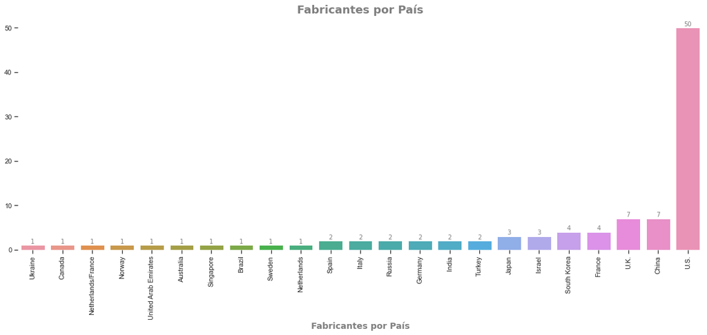

```python
univariate_single_plot(x="country", xlabel="Fabricantes por País", rotation=90, bar_label=True)
```

- O Estados Unidos, a China e o Reino Unido são os países que detém a maior quantidade de fabricantes listadas neste ranking;
- O Estados Unidos apresenta 7 vezes mais fabricantes do que a China/Reino Unido.
- Das 100 melhores fabricantes de 2020, 50 tem origem nos Estados Unidos, o que equivale a 50% da quantidade total de fabricantes nesta lista;
- Uma fabricante da lista é de origem brasileira.

### 3.1.2. RECEITA DE DEFESA (2020)

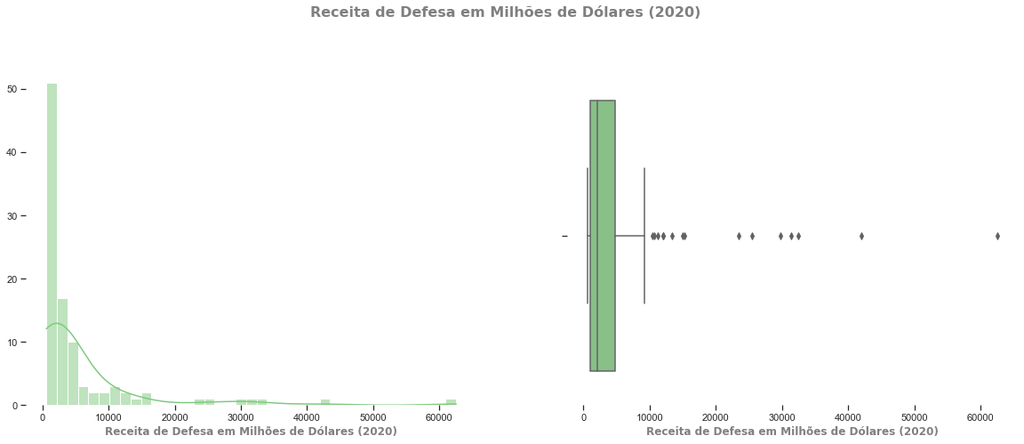

```python
univariate_numerical_plot(df=df, x='defense_revenue_2020', xlabel="Receita de Defesa em Milhões de Dólares (2020)", bar_label=True)
```

```python
describetter(df['defense_revenue_2020'], 'defense_revenue_2020')
```

|  | defense_revenue_2020 |
| --- | --- |
| count | 100.000000 |
| mean | 5512.216700 |
| std | 9455.415446 |
| min | 594.330000 |
| 25% | 1023.810000 |
| 50% | 2103.250000 |
| 75% | 4746.385000 |
| max | 62562.000000 |
| min_no | 594.330000 |
| max_no | 9228.360000 |

### 3.1.3. RECEITA DE DEFESA (2019)

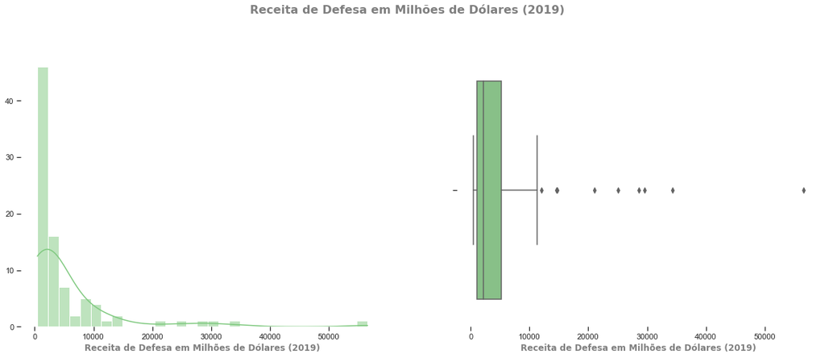

```python
univariate_numerical_plot(df=df, x='defense_revenue_2019', xlabel="Receita de Defesa em Milhões de Dólares (2019)", bar_label=True)
```

```python
describetter(df['defense_revenue_2019'], 'defense_revenue_2019')
```

|  | defense_revenue_2019 |
| --- | --- |
| count | 89.000000 |
| mean | 5336.247303 |
| std | 8601.611884 |
| min | 449.820000 |
| 25% | 1081.430000 |
| 50% | 2115.000000 |
| 75% | 5182.960000 |
| max | 56606.000000 |
| min_no | 449.820000 |
| max_no | 11266.570000 |

Nota: 11 fabricantes foram removidas desta análise pois possuem valores nulos.

### 3.1.4. VARIAÇÃO NA RECEITA DE DEFESA (2019 PARA 2020)

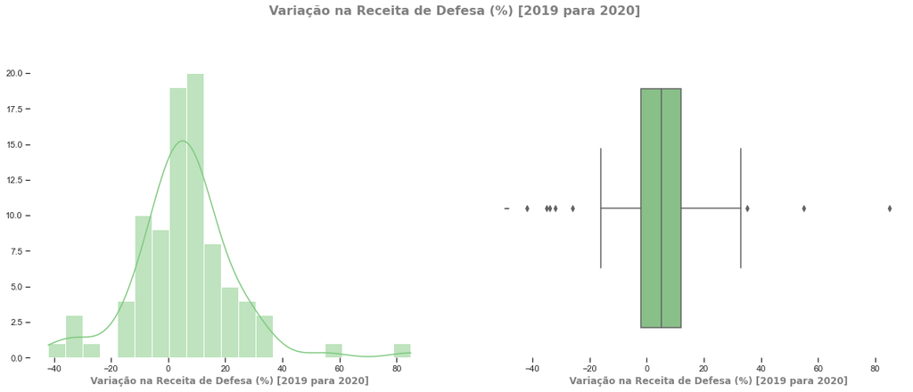

```python
univariate_numerical_plot(df=df, x='percent_defense_revenue_change', xlabel="Variação na Receita de Defesa (%) [2019 para 2020]", bar_label=True)
```

```python
describetter(df['percent_defense_revenue_change'], 'percent_defense_revenue_change')
```

|  | percent_defense_revenue_change |
| --- | --- |
| count | 89.000000 |
| mean | 5.719101 |
| std | 17.635829 |
| min | -42.000000 |
| 25% | -2.000000 |
| 50% | 5.000000 |
| 75% | 12.000000 |
| max | 85.000000 |
| min_no | -16.000000 |
| max_no | 31.000000 |

Nota: 11 fabricantes foram removidas desta análise pois possuem valores nulos.

### 3.1.5. RECEITA TOTAL (2020)

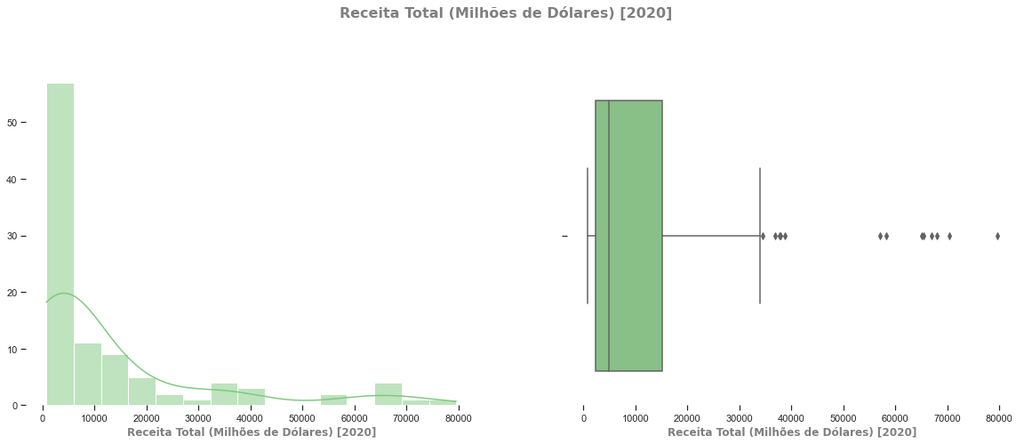

```python
univariate_numerical_plot(df=df, x='total_revenue_2020', xlabel="Receita Total (Milhões de Dólares) [2020]", bar_label=True)
```

```python
describetter(df['total_revenue_2020'], 'total_revenue_2020')
```

|  | total_revenue_2020 |
| --- | --- |
| count | 100.000000 |
| mean | 13146.305200 |
| std | 18594.281999 |
| min | 747.700000 |
| 25% | 2251.652500 |
| 50% | 4824.230000 |
| 75% | 15145.847500 |
| max | 79619.000000 |
| min_no | 747.700000 |
| max_no | 33977.450000 |

### 3.1.6. PROPORÇÃO - RECEITA DE DEFESA X RECEITA TOTAL (2020)

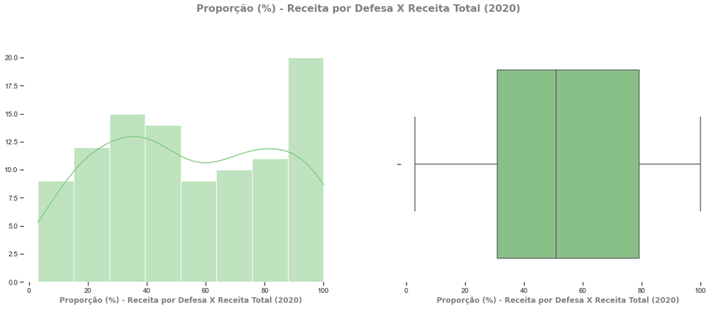

```python
univariate_numerical_plot(df=df, x='revenue_from_defense', xlabel="Proporção (%) - Receita por Defesa X Receita Total (2020)", bar_label=True)
```

```python
describetter(df['revenue_from_defense'], 'revenue_from_defense')
```

|  | revenue_from_defense |
| --- | --- |
| count | 100.000000 |
| mean | 54.710000 |
| std | 29.535904 |
| min | 3.000000 |
| 25% | 31.000000 |
| 50% | 51.000000 |
| 75% | 79.250000 |
| max | 100.000000 |
| min_no | 3.000000 |
| max_no | 100.000000 |

- A média é que 54% da receita total provém da receita de defesa;
- O desvio padrão é de 29%;

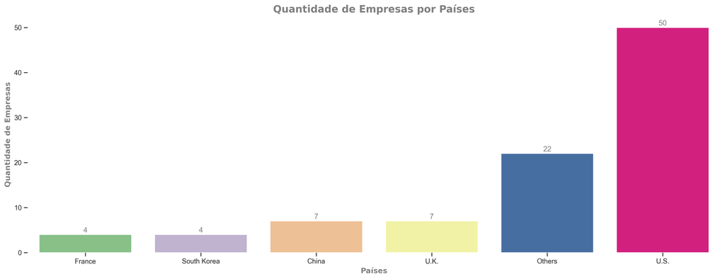

```python
#
#
#
#
#REALOCAR CÉLULA POSTERIORMENTE
#
#
#
#

temp_df = df['country'].value_counts().rename_axis('pais').reset_index(name='contagem')

temp_df_others = temp_df[temp_df.contagem < 3]

others = {}
others['pais'] = 'Others'
others['contagem'] = temp_df_others['contagem'].sum()
others = pd.DataFrame.from_dict([others])

new_df = temp_df
new_df.drop(temp_df[temp_df.contagem < 4].index, inplace=True)
new_df = pd.concat([new_df, others], ignore_index=True)

#univariate_single_plot(new_df, x="contagem", xlabel="Países", rotation=90, bar_label=True)
#univariate_multi_plot(new_df, x='pais', xlabel='Países', explode=None)
multivariate_plot(new_df, title='Quantidade de Empresas por Países', x='pais', y='contagem', hue=None, xlabel='Países', ylabel='Quantidade de Empresas', rotation=None, bar_label=True,
                      legend=False, rotate_label=False)
```